# Q2_ZHANG, XIAO_17204147

ZHANG, XIAO (17204147)

2020/6/9

```r
library(ggplot2)
```

##Load packages

```r
data <- read.csv("data.csv")
```

## Input the dataset from the local disk. The dataset contains the number of the recovered and death cases in Malaysia from 01/22/2020~06/07/2020.

```r
head(data)
```

```
##      Date Recovered Deaths
## 1 1/22/20         0      0
## 2 1/23/20         0      0
## 3 1/24/20         0      0
## 4 1/25/20         0      0
## 5 1/26/20         0      0
## 6 1/27/20         0      0
```

## It shows the first 6 rows in the dataset. We can see that the first column implies the date when data collected, second is the Recovered cases and third is Deaths.

```r
tail(data)
```

```
##          Date Recovered Deaths
## 133 2006/2/20      6470    115
## 134 2006/3/20      6531    115
## 135 2006/4/20      6559    115
## 136 2006/5/20      6610    116
## 137 2006/6/20      6635    117
## 138 2006/7/20      6674    117
```

## This are the last 6 rows.

```r
dim(data)
```

```
## [1] 138   3
```

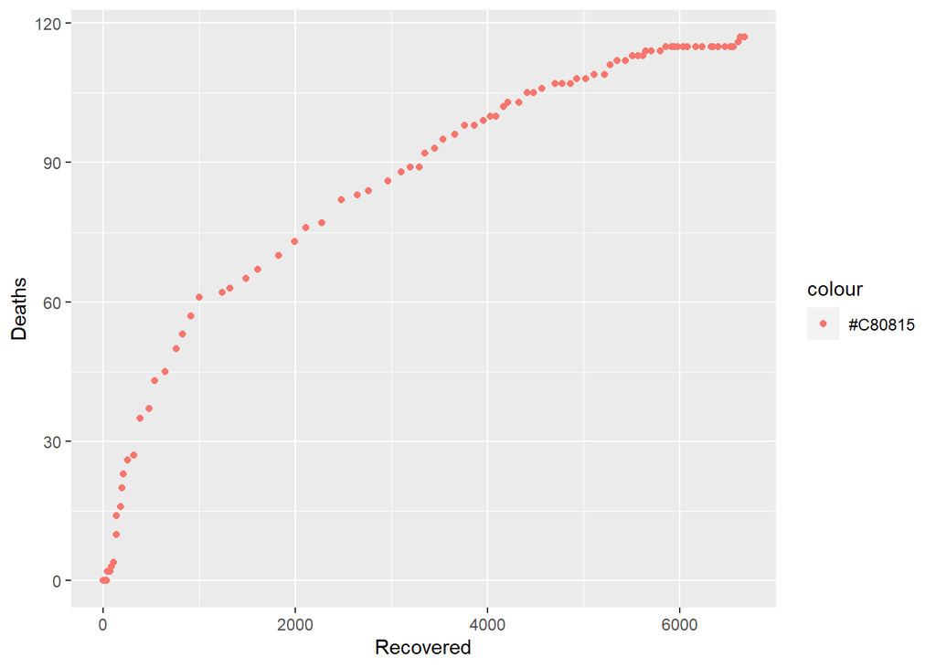

```r
input <- data[,c('Recovered', 'Deaths')]
ggplot(input, aes(x=Recovered, y=Deaths, col="#C80815" ))+geom_point()
```

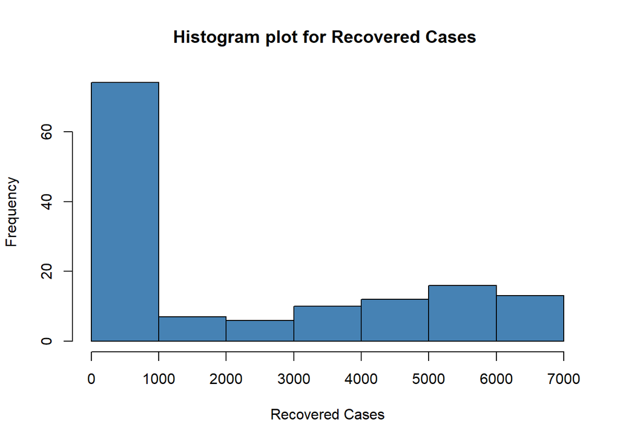

```r
hist(data$Recovered,col="steelblue",xlab="Recovered Cases", main='Histogram plot for Recovered Cases ')
```

## Plot the histogram for “Recovered Cases”

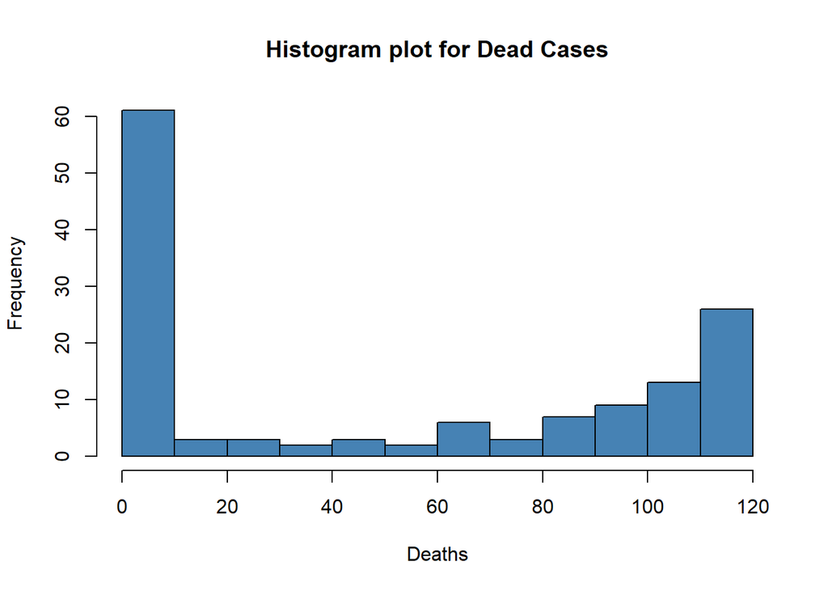

```r
hist(data$Deaths,col="steelblue", xlab="Deaths", main='Histogram plot for Dead Cases')
```

## Plot the histogram for “Death Cases”

```r
df <- data[which(rowSums(data==0)==0),]
```

## Clean the zero numbers, since too many empty values may distruct the plot.

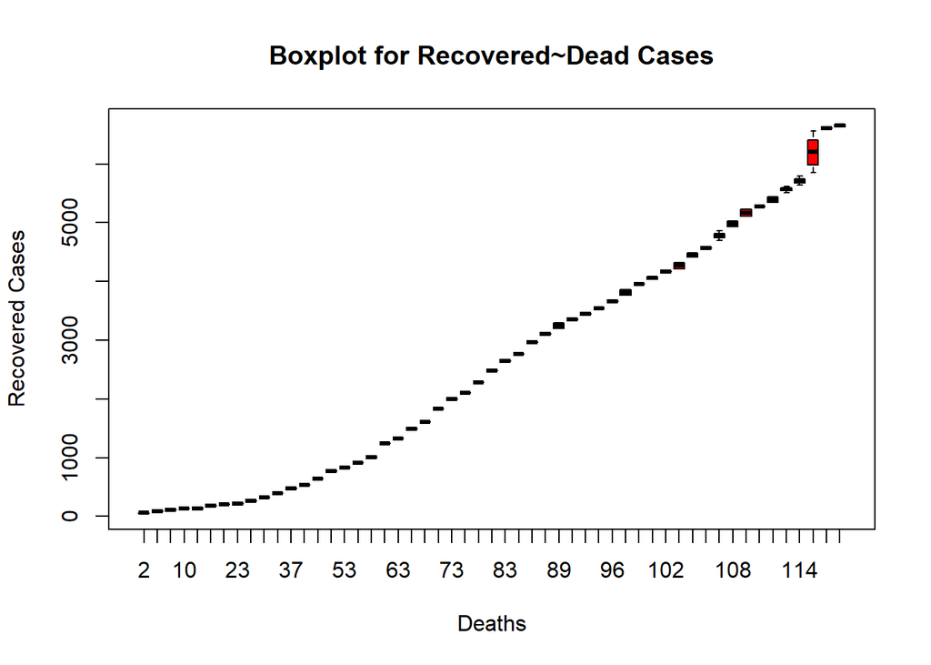

```r
boxplot(Recovered~Deaths, data=df, xlab='Deaths', ylab = 'Recovered Cases', main='Boxplot for Recovered~Dead Cases', col="red")
```

## Plot a boxplot to show the realationship between Recovered and Death numbers. It indicates that those two variables has a correlated upheaval relationship. The force to rise up and get down between those two are Complementary.